# Projekt - Skalowanie Wielowymiarowe

Jakub Anczyk

2023-11-12

# Skalowanie Wielowymiarowe

## Wstęp

W niniejszej pracy zastosuję dwa przykłady skalowania wielowymiarowego na danych wykorzystanych w analizie dotyczącej porządkowania liniowego i analizy skupień. Celem pracy jest bliższe poznanie różnych technik skalowania wielowymiarowego oraz dokłada analiza zestawu danych dotyczącego zawartości związków odżywczych w różnego rodzaju produktach.

Ważne: **Dane pochodzą z gotowego zbioru danych zawierającego produkty dostępne na rynku amerykańskim, więc wyniki nie są doskonałe i nie należy się nimi sugerować w kształtowaniu własnych nawyków żywieniowych.**

## Dane

Do projektu wybrałem zestaw danych dotyczący zawartości wartości odżywczych w różnego rodzaju produktach spożywczych, znaleziony na stronie [Kaggle](https://www.kaggle.com/code/niharika41298/food-nutrition-analysis-eda/input). Dane zastosowane w tej części projektu zostały uprzednio wyczyszczone i skrócone w pierwszej jego części.

```r
data <- read.csv("nutrition_cleaned.csv",row.names = 1)
```

## Analiza podstawowych statystyk

Za pomocą funkcji descr() z biblioteki summarytools dokonuję szybkiej analizy wybranych danych.

Kalorie: Średnia zawartość kalorii wynosi 256,70, przy znacznym odchyleniu standardowym wynoszącym 134,60. Zakres jest znaczny, od minimum 78,72 do maksimum 783,33, co wskazuje na zróżnicowany zakres produktów spożywczych.

### Tłuszcz:

Średnia zawartość tłuszczu wynosi 17.10, a dane są dodatnio skośne (skośność = 2.51), co sugeruje rozkład prawoskośny z kilkoma pozycjami o wysokiej zawartości tłuszczu. Wartość kurtozy wynosząca 8.51 wskazuje na rozkład leptokurtyczny, tj. ciężkie ogony i potencjalne wartości odstające.

### Białko:

Średnia zawartość białka w zbiorze danych wynosi 21.71, przy stosunkowo niskim odchyleniu standardowym wynoszącym 6.26. Rozkład jest ujemnie skośny (skośność = -0.68), co sugeruje, że jest więcej produktów o wyższej zawartości białka.

### Tłuszcz nasycony:

Zawartość tłuszczów nasyconych ma średnią 10,89, a dane są dodatnio skośne (skośność = 1.08), co oznacza rozkład prawoskośny. Zakres międzykwartylowy (IQR) jest stosunkowo szeroki, co wskazuje na zmienność poziomów tłuszczów nasyconych wśród produktów spożywczych.

### Zgodność danych

Odsetek prawidłowych danych wynosi 100% dla wszystkich atrybutów, co wskazuje na kompletny zbiór danych bez brakujących wartości.

```r
descr(data)
```

```
## Descriptive Statistics
## data
## N: 48
##
##                     Calories    Carbs      Fat   Protein   Sat.Fat
## ----------------- ---------- -------- -------- --------- ---------
##              Mean     256.70     1.37    17.10     21.71     10.89
##           Std.Dev     134.60     3.11    15.70      6.26     11.88
##               Min      78.72     0.00     1.00      5.00      0.00
##                Q1     174.29     0.00     8.00     18.00      0.00
##            Median     217.65     0.00    12.05     22.58      8.24
##                Q3     316.77     0.00    21.90     27.00     17.65
##               Max     783.33    14.10    91.67     33.93     43.75
##               MAD     105.57     0.00     9.06      6.64     12.21
##               IQR     131.08     0.00    13.45      9.00     17.65
##                CV       0.52     2.28     0.92      0.29      1.09
##          Skewness       1.56     2.37     2.51     -0.68      1.08
##       SE.Skewness       0.34     0.34     0.34      0.34      0.34
##          Kurtosis       3.35     5.09     8.51      0.13      0.44
##           N.Valid      48.00    48.00    48.00     48.00     48.00
##         Pct.Valid     100.00   100.00   100.00    100.00    100.00
```

## Standaryzacja

Przed przystąpieniem do kolejnych kroków standaryzuję dane i tworzę macierz odległości.

```r
data_st <- as.data.frame(scale(data))
odl <- dist(data_st)
```

## Klasyczne skalowanie wielowymiarowe

W poniższym kodzie przeprowadzam klasyczne skalowanie wielowymiarowe dla dwóch wymiarów i obliczam położenie marginesów wykresu.

```r
sww2 <- cmdscale(odl, k=2)
sww2
```

```
##                                [,1]        [,2]
## Salt pork               -5.27851751  1.65110978
## Bacon                   -3.89093086  0.47763099
## Beef                    -0.39049589 -0.96150618
## Hamburger               -0.49390945 -0.69367905
## Ground lean              0.51483083 -1.03871278
## Roast beef              -3.22079103 -0.19059451
## Steak                   -1.90320148 -0.64471098
## Steak, lean, as round    0.14254556 -1.06512990
## Corned beef              0.45667858 -0.77498828
## Corned beef hash canned  0.91106481  2.18283240
## Corned beef hash Dried   1.02776399 -1.66455436
## Pot-pie                  0.42639644  4.42736470
## Corned beef hash Stew    1.35894753  2.93695136
## chicken                  0.62564127 -0.89546077
## chicken, fried          -0.09783181 -1.19834854
## Roasted chicken         -0.42842291 -0.71661980
## Chicken livers, fried    0.64006951  0.21488553
## Duck, domestic          -0.67876162  0.38820570
## Lamb, chop, broiled     -2.02148208 -0.36005579
## Leg roasted             -0.68098676 -0.57083753
## Shoulder, braised       -1.35045276 -0.34181652
## Pork, chop, 1 thick     -0.63341590  0.29638270
## Ham pan-broiled         -1.29545236 -0.06943512
## Ham, as                 -0.76072948 -0.48658251
## Ham, canned, spiced     -1.02290357  0.89200494
## Pork roast              -1.44215526 -0.74696493
## Pork sausage            -3.33071578 -0.09231642
## Turkey                   0.57043797 -0.84125893
## Veal                     0.57832864 -0.90320697
## Roast                   -0.81691622  0.33160915
## Clams                    1.59388704  1.16211825
## Cod                      1.41162650 -0.94407858
## Crab meat                1.55532785  0.63479268
## Fish sticks fried        0.98423996  1.88854856
## Flounder                 1.20929662 -1.17172026
## Haddock                  1.22488939  1.65811551
## Halibut                  1.19224356 -0.71502607
## Herring                  0.76922598 -0.26273121
## Lobster                  1.67285956  0.19903929
## Mackerel                 0.97185253 -0.16552902
## Oyster stew              1.24980343 -0.30104822
## Salmon                   1.26364640 -0.03869349
## Sardines                 0.76523695 -0.73762708
## Scallops                 1.65000081  2.47941879
## Shad                     0.90454174 -0.43334946
## Shrimp                   1.71992885 -0.83306562
## Swordfish                1.30299202 -0.83315428
## Tuna                     1.04376840 -1.12820719
```

```r
xmarg <- c(min(sww2[,1])-1, max(sww2[,1])+1)
ymarg <- c(min(sww2[,2])-1, max(sww2[,2])+1)
```

Przy zredukowaniu zestawu danych do dwóch wymiarów współczynnik STRESS wynosi 0.15175.

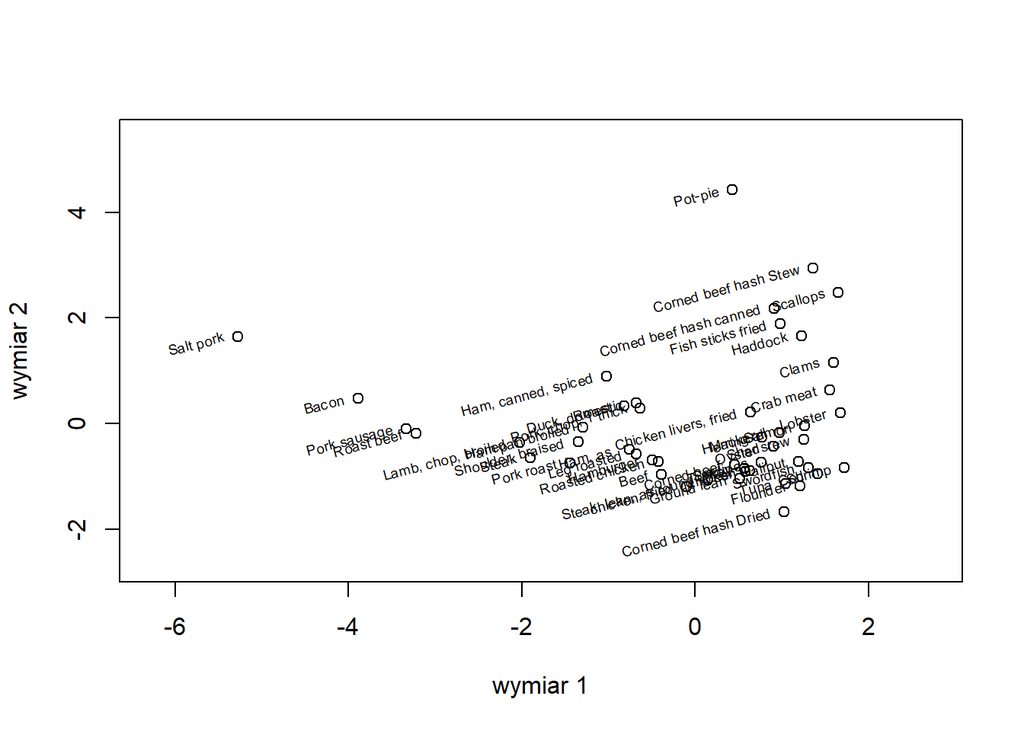

```r
plot(sww2, xlab = "wymiar 1", ylab = "wymiar 2", xlim = xmarg, ylim = ymarg)
text(sww2, labels = rownames(data), pos = 2, cex = 0.6, srt = 15)
```

```r
odl2 <- dist(sww2)

stress <- function(d1, d2){
  sqrt(sum((d1-d2)^2)/sum(d1^2))
}

stress(odl,odl2)
```

```
## [1] 0.1517572
```

Zredukowanie danych do trzech wymiarów pozwala zaobserwować, że redukcja tylko do dwóch istotnie ogranicza możliwości interpretacji danych i skutkuje utratą ważnego kontekstu.

Dane wszystkich obserwacji wyraźnie skupiają się wokół pewnego centrum. To tutaj znajduje się największe skupisko obserwacji. W każdym z trzech wymiarów znajdują się jednak outlierzy.

Poniższy wykres jest interaktywny i pozwala na przybliżanie i oddalanie widoku.

```r
sww3 <- cmdscale(odl, k=3)
sww3
```

```
##                                [,1]        [,2]        [,3]
## Salt pork               -5.27851751  1.65110978  3.70827539
## Bacon                   -3.89093086  0.47763099 -2.07277927
## Beef                    -0.39049589 -0.96150618 -0.47667180
## Hamburger               -0.49390945 -0.69367905 -0.31047569
## Ground lean              0.51483083 -1.03871278 -0.30786621
## Roast beef              -3.22079103 -0.19059451 -0.83837533
## Steak                   -1.90320148 -0.64471098 -0.65926850
## Steak, lean, as round    0.14254556 -1.06512990 -0.37004261
## Corned beef              0.45667858 -0.77498828 -0.16115017
## Corned beef hash canned  0.91106481  2.18283240 -0.48642404
## Corned beef hash Dried   1.02776399 -1.66455436 -0.54085640
## Pot-pie                  0.42639644  4.42736470 -1.22956277
## Corned beef hash Stew    1.35894753  2.93695136  0.21901703
## chicken                  0.62564127 -0.89546077 -0.10958050
## chicken, fried          -0.09783181 -1.19834854 -0.35405240
## Roasted chicken         -0.42842291 -0.71661980 -0.22587528
## Chicken livers, fried    0.64006951  0.21488553 -0.40348242
## Duck, domestic          -0.67876162  0.38820570  1.53382064
## Lamb, chop, broiled     -2.02148208 -0.36005579 -0.44084711
## Leg roasted             -0.68098676 -0.57083753 -0.11691897
## Shoulder, braised       -1.35045276 -0.34181652 -0.35729165
## Pork, chop, 1 thick     -0.63341590  0.29638270  0.19759888
## Ham pan-broiled         -1.29545236 -0.06943512 -0.07946632
## Ham, as                 -0.76072948 -0.48658251 -0.23641370
## Ham, canned, spiced     -1.02290357  0.89200494 -0.04668791
## Pork roast              -1.44215526 -0.74696493 -0.52697763
## Pork sausage            -3.33071578 -0.09231642 -0.67054932
## Turkey                   0.57043797 -0.84125893  0.52232674
## Veal                     0.57832864 -0.90320697 -0.18178438
## Roast                   -0.81691622  0.33160915  0.43653523
## Clams                    1.59388704  1.16211825  0.56447128
## Cod                      1.41162650 -0.94407858  0.19455892
## Crab meat                1.55532785  0.63479268  0.62160108
## Fish sticks fried        0.98423996  1.88854856 -0.41409251
## Flounder                 1.20929662 -1.17172026  0.15105064
## Haddock                  1.22488939  1.65811551 -0.60313991
## Halibut                  1.19224356 -0.71502607  0.38155221
## Herring                  0.76922598 -0.26273121  0.74423510
## Lobster                  1.67285956  0.19903929  0.66990180
## Mackerel                 0.97185253 -0.16552902  0.72554716
## Oyster stew              1.24980343 -0.30104822  0.48445542
## Salmon                   1.26364640 -0.03869349  0.60550979
## Sardines                 0.76523695 -0.73762708  0.17420756
## Scallops                 1.65000081  2.47941879 -0.73716419
## Shad                     0.90454174 -0.43334946  0.61685600
## Shrimp                   1.71992885 -0.83306562  0.14728204
## Swordfish                1.30299202 -0.83315428  0.28398002
## Tuna                     1.04376840 -1.12820719 -0.02498597
```

```r
plot3d(sww3, xlab = "wymiar 1", ylab = "wymiar 2", zlab = "wymiar 3")
text3d(sww3, texts=rownames(data), cex = 0.6, srt = 15)
rglwidget()
```

[interactive chart not shown]

```r
odl3 <- dist(sww3)
stress(odl,odl3)
```

```
## [1] 0.05835718
```

### 1 Wymiar

Na trójwymiarowym wykresie najbardziej skrajną obserwacją w 1 wymiarze jest “salt pork”, która znajduje się na samym skraju wartości negatywnych (około -5). Pozostałe obserwacje,z nielicznymi wyjątkami, skupiają się wokół wartości od 0 do 1. Na wykresie dwuwymiarowym możemy zaobserwować podobne zachowanie się tej obserwacji.

Na tak skrajny wynik tej potrawy składają się bardzo skrajne pomiary zmiennych Calories, Protein, Fat oraz Sat.Fat:

```r
data["Salt pork",]
```

```
##           Calories Protein      Fat Sat.Fat Carbs
## Salt pork 783.3333       5 91.66667       0     0
```

### 2 Wymiar

W drugim wymiarze trójwymiarowego wykresu sytuacja jest niemal identyczna, z tą jednak różnicą, ze wartością skrajną jest “pot-pie”, które osiąga największą wartość (4), podczas gdy pozostałe obserwacje koncentrują się wokół wartości od 0 do -1. Na wykresie dwuwymiarowym możemy zaobserwować w zasadzie identyczne rozłożenie zmiennych.

Położenie “pot-pie” bezpośrednio wynika ze skrajności pomiarów zmiennych Protein i Carbs.

```r
data["Pot-pie",]
```

```
##         Calories  Protein     Fat  Sat.Fat    Carbs
## Pot-pie 211.4537 7.929515 12.3348 11.01322 14.09692
```

### Różnice pomiędzy “Salt porK” oraz “Bacon”

Odróżnienie tych dwóch obserwacji jest istotne, ponieważ wyraźnie różnią się one pomiarem zmiennych Protein (5g dla “Salt porK” vs. 25g dla “Bacon”), Fat (91.7g dla “Salt pork” vs. 50g dla “Bacon”), Sat.Fat (0.0g dla “Salt pork” vs. 43.75g dla “Bacon”) oraz Carbs (0.0g dla “Salt pork” vs. 6.25g dla “Bacon”).

Powodem bliskiego ich umiejscowienia na wykresie dwuwymiarowym może być fakt, że obie te obserwacje osiągają dwie najwyższe (choć znacznie oddalone od siebie) wartości dla zmiennych Calories (783.3g dla “Salt pork” vs. 593.75g dla “Bacon”) oraz Fat (91.67g dla “Salt pork” vs. 50g dla “Bacon”).

Te znaczące różnice doskonale obrazuje współczynnik STRESS dla obu wersji wykresów. Bazując na tym wskaźniku, możemy uznać, że utrata informacji przy redukcji liczby wymiarów o tylko jeden skutkuje utratą informacji aż o 260%.

```r
stress(odl,odl2)
```

```
## [1] 0.1517572
```

```r
stress(odl,odl3)
```

```
## [1] 0.05835718
```

```r
((stress(odl,odl2)/stress(odl,odl3))*100)
```

```
## [1] 260.0488
```

## Metoda Sammona

W tej części przeprowadzę skalowanie metodą Sammona z wykorzystaniem funkcji Sammon() z pakietu MASS.

```r
sammon2 <- sammon(odl, k=2)
```

```
## Initial stress        : 0.02834
## stress after  10 iters: 0.00965, magic = 0.500
## stress after  20 iters: 0.00944, magic = 0.500
## stress after  30 iters: 0.00942, magic = 0.500
```

```r
sammon2$points
```

```
##                               [,1]        [,2]
## Salt pork               -5.5822762  3.94024727
## Bacon                   -4.6118807  0.53562115
## Beef                    -0.4743428 -1.15531152
## Hamburger               -0.5595162 -0.81581184
## Ground lean              0.4031125 -1.21664091
## Roast beef              -3.3741786 -0.68382343
## Steak                   -1.9943879 -0.87622949
## Steak, lean, as round    0.0614166 -1.24978299
## Corned beef              0.3674138 -0.82646247
## Corned beef hash canned  0.7276602  2.28496022
## Corned beef hash Dried   0.8937446 -2.11583437
## Pot-pie                  0.4032002  4.66695063
## Corned beef hash Stew    2.2199498  2.71308395
## chicken                  0.5664054 -1.00005775
## chicken, fried          -0.1321882 -1.49249849
## Roasted chicken         -0.4390374 -0.81753973
## Chicken livers, fried    0.4668815  0.30721525
## Duck, domestic          -0.4772492  1.24588616
## Lamb, chop, broiled     -2.1074220 -0.44400643
## Leg roasted             -0.6740674 -0.41142873
## Shoulder, braised       -1.4588389 -0.41572435
## Pork, chop, 1 thick     -0.6946554  0.46554333
## Ham pan-broiled         -1.3816102 -0.03676001
## Ham, as                 -0.8517677 -0.60283299
## Ham, canned, spiced     -1.2353251  0.92743139
## Pork roast              -1.5008241 -0.96517690
## Pork sausage            -3.4472199 -0.48003342
## Turkey                   0.8409212 -1.22879201
## Veal                     0.4794818 -1.01092766
## Roast                   -0.9279393  0.63515306
## Clams                    1.9774375  1.06888191
## Cod                      1.4601832 -1.13124278
## Crab meat                1.8482622  0.62345158
## Fish sticks fried        0.9327638  1.96580639
## Flounder                 1.3039671 -1.47214922
## Haddock                  1.1819237  1.80787579
## Halibut                  1.2856935 -0.81808919
## Herring                  0.9372944 -0.20026345
## Lobster                  2.0283784  0.24745680
## Mackerel                 1.1438680 -0.08412951
## Oyster stew              1.4119138 -0.27797771
## Salmon                   1.4788479  0.06772385
## Sardines                 0.8187178 -0.81042331
## Scallops                 1.4114249  2.90396811
## Shad                     1.0602661 -0.43542988
## Shrimp                   1.7840414 -0.97051353
## Swordfish                1.3709728 -0.98245063
## Tuna                     1.0585831 -1.37891215
```

```r
sammon2$stress
```

```
## [1] 0.009422726
```

Po wygenerowaniu wykresu widzimy natychmiast wyraźną różnicę w rozmieszczeniu “salt pork” i “bacon”, których znaczne różnice są na wykresie dwuwymiarowym skalowania metodą Sammona dużo wyraźniejsze, niż w przypadku klasycznej metody.

Pozostałe obserwacje również zmieniły umiejscowienie na wykresie, choć nieznacznie.

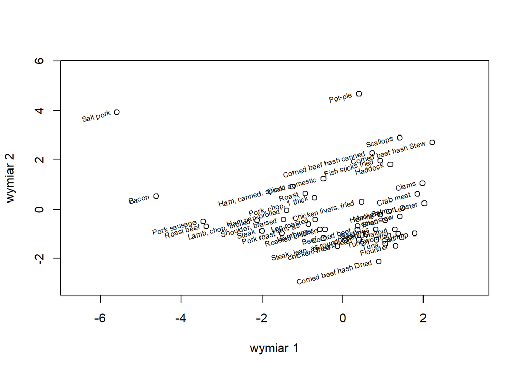

```r
xmargsmn <- c(min(sammon2$points[,1])-1, max(sammon2$points[,1])+1)
ymargsmn <- c(min(sammon2$points[,2])-1, max(sammon2$points[,2])+1)

plot(sammon2$points, xlab = "wymiar 1", ylab = "wymiar 2", xlim = xmargsmn, ylim = ymargsmn)
text(sammon2$points, labels = rownames(data), pos = 2, cex = 0.6, srt = 15)
```

Z kolei w trzech wymiarach zarówno umiejscowienie pojedynczych obserwacji jak wnioski pozostają niemal tożsame z wnioskami z analizy metody klasycznej.

Poniższy wykres jest interaktywny i pozwala na przybliżanie i oddalanie widoku.

```r
sammon3 <- sammon(odl,k=3)
```

```
## Initial stress        : 0.00617
## stress after  10 iters: 0.00112, magic = 0.500
## stress after  20 iters: 0.00101, magic = 0.500
## stress after  30 iters: 0.00099, magic = 0.500
```

```r
sammon3$points
```

```
##                                [,1]        [,2]        [,3]
## Salt pork               -5.36388663  1.75710155  3.82320876
## Bacon                   -3.73558226  0.56532326 -2.68349067
## Beef                    -0.37973369 -0.95472990 -0.52321035
## Hamburger               -0.49849703 -0.63618384 -0.35858838
## Ground lean              0.53693811 -1.01975541 -0.38879351
## Roast beef              -3.34246995 -0.19612009 -0.66589427
## Steak                   -1.91211060 -0.61849138 -0.69690422
## Steak, lean, as round    0.16526333 -1.08448122 -0.42983995
## Corned beef              0.44755568 -0.70240322 -0.20502967
## Corned beef hash canned  0.91629486  2.20959602 -0.39763341
## Corned beef hash Dried   1.10615741 -1.76632120 -0.68485576
## Pot-pie                  0.57338368  4.40497430 -1.50742791
## Corned beef hash Stew    1.26177826  3.03842022  0.67882942
## chicken                  0.63883429 -0.89550044 -0.15999663
## chicken, fried          -0.04810857 -1.35174188 -0.42100856
## Roasted chicken         -0.41617578 -0.70577188 -0.27086037
## Chicken livers, fried    0.63545134  0.31159320 -0.41947128
## Duck, domestic          -0.62902236  0.14074343  1.71511837
## Lamb, chop, broiled     -2.07936482 -0.34331658 -0.34725768
## Leg roasted             -0.78008176 -0.73708823  0.21094607
## Shoulder, braised       -1.39946381 -0.21982089 -0.36792424
## Pork, chop, 1 thick     -0.75279133  0.58112035  0.25107602
## Ham pan-broiled         -1.37170785  0.04378223 -0.03469636
## Ham, as                 -0.77697854 -0.38692605 -0.30009433
## Ham, canned, spiced     -1.13160265  1.04084263  0.03330898
## Pork roast              -1.42919336 -0.76056354 -0.58814802
## Pork sausage            -3.43085757 -0.07151697 -0.50214909
## Turkey                   0.62153269 -1.20673731  0.55539837
## Veal                     0.58565186 -0.87219098 -0.23744241
## Roast                   -0.99769174  0.41150992  0.77928457
## Clams                    1.48544309  1.27334258  0.90392254
## Cod                      1.44843174 -1.01516979  0.11892810
## Crab meat                1.46762657  0.75715753  0.91099648
## Fish sticks fried        1.11264948  1.81259435 -0.72563672
## Flounder                 1.27695886 -1.38924752  0.06850780
## Haddock                  1.36213933  1.57632828 -0.82597990
## Halibut                  1.21799076 -0.79855088  0.33277242
## Herring                  0.75448516 -0.37183171  0.74783709
## Lobster                  1.62078511  0.36453560  1.05339008
## Mackerel                 0.94555121 -0.18019819  0.73631386
## Oyster stew              1.25401809 -0.20995565  0.48570563
## Salmon                   1.24668831  0.09953114  0.70571382
## Sardines                 0.78918266 -0.77584331  0.12708853
## Scallops                 1.90802463  2.34268026 -1.30149539
## Shad                     0.91036957 -0.54316448  0.60259120
## Shrimp                   1.75426270 -0.77577095  0.09588793
## Swordfish                1.33512768 -0.91377366  0.22327886
## Tuna                     1.09674384 -1.22800970 -0.11627580
```

```r
sammon3$stress
```

```
## [1] 0.0009923314
```

```r
plot3d(sammon3$points, xlab = "wymiar 1", ylab = "wymiar 2", zlab = "wymiar 3")
text3d(sammon3$points, texts= rownames(data), pos = 2, cex = 0.6, srt = 15)
rglwidget()
```

[interactive chart not shown]

Wbudowana w pakiet MASS funkcja pozwalająca obliczyć wartość STRESS wskazuje na dużą utratę informacji przy redukcji z trzech do dwóch wymiarów metodą Sammona (949.55).

```r
((sammon2$stress/sammon3$stress)*100)
```

```
## [1] 949.5544
```

Po zastosowaniu standardowego wzoru do obliczenia współczynnika STRESS uzyskujemy już jednak wartość bardziej zbliżoną do tej uzyskanej metodą klasyczną (286.00 dla metody Sammona vs 260.04 dla metody klasycznej), co może świadczyć o dużym podobieństwie obu metod w tym konkretnym przykładzie.

```r
((stress(odl, dist(sammon2$points))/stress(odl, dist(sammon3$points)))*100)
```

```
## [1] 286.0027
```

## Podsumowanie

Obie zastosowane metody dają bardzo podobne rezultaty, jednak metoda Sammona w (na tym konkretnym przykładzie) jest dokładniejsza w przypadku redukcji wymiarów wartości, które są zarówno bardzo skrajne w porównaniu do pozostałych obserwacji, ale także znacznie się między sobą różnią.

Na podstawie analizy współczynnika STRESS można przypuścić, że dzieje się to kosztem dokładności redukcji wymiarów obserwacji, które są do siebie bardziej podobne.